# Coding Assignment 1

Team 11

Due: 2021-09-29 23:59

```r
# Put any packages you want here
library(readxl)
library(dplyr)
```

```r
library(gt)
library(gtsummary)
library(corrplot)
library(car)
library(jtools)
```

A Florida health insurance company wants to predict annual claims for individual clients. The company pulls a random sample of 50 customers. The owner wishes to charge an actuarially fair premium to ensure a normal rate of return. The owner collects all of their current customer’s health care expenses from the last year and compares them with what is known about each customer’s plan.

The data on the 50 customers in the sample is as follows:

- Charges: Total medical expenses for a particular insurance plan (in dollars)
- Age: Age of the primary beneficiary
- BMI: Primary beneficiary’s body mass index (kg/m2)
- Female: Primary beneficiary’s birth sex (0 = Male, 1 = Female)
- Children: Number of children covered by health insurance plan (includes other dependents as well)
- Smoker: Indicator if primary beneficiary is a smoker (0 = non-smoker, 1 = smoker)
- Cities: Dummy variables for each city with the default being Sanford

Answer the following questions using complete sentences and attach all output, plots, etc. within this report.

**For this assignment, ignore the categorical variables (gender, smoker, cities)**

# Question 1

Perform univariate analyses on the quantitative variables (center, shape, spread). Include descriptive statistics, and histograms. Be sure to use terms discussed in class such as bimodal, skewed left, etc.

```r
mean(insurance$Charges)
```

```
## [1] 10860.18
```

```r
median(insurance$Charges)
```

```
## [1] 7814.885
```

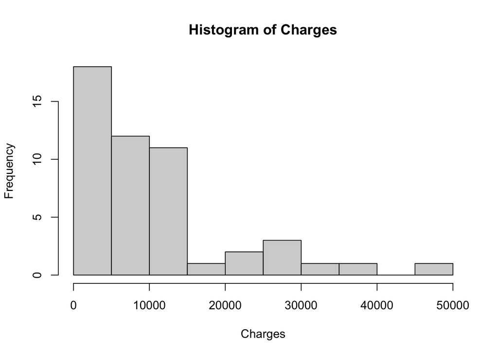

```r
hist(insurance$Charges,
     main = 'Histogram of Charges',
     xlab = 'Charges',
     ylab = 'Frequency')
```

```r
var(insurance$Charges)
```

```
## [1] 97681418
```

```r
mean(insurance$Age)
```

```
## [1] 39.32
```

```r
median(insurance$Age)
```

```
## [1] 38
```

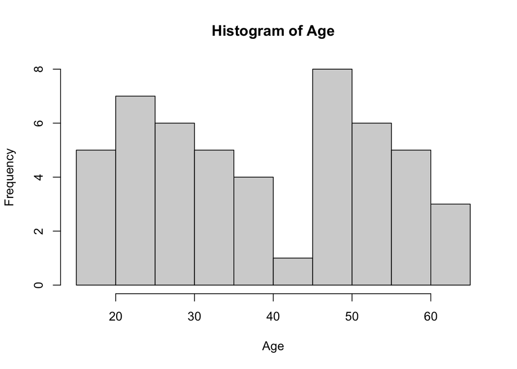

```r
hist(insurance$Age,
     main = 'Histogram of Age',
     xlab = 'Age',
     ylab = 'Frequency')
```

```r
var(insurance$Age)
```

```
## [1] 205.8955
```

```r
mean(insurance$BMI)
```

```
## [1] 30.0219
```

```r
median(insurance$BMI)
```

```
## [1] 29.865
```

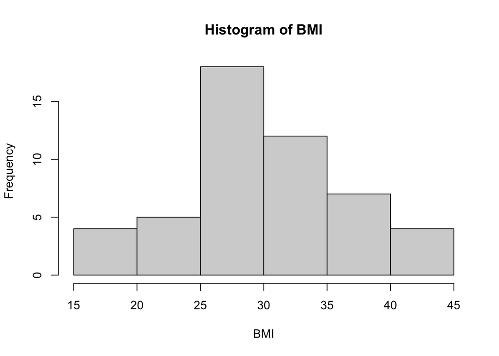

```r
hist(insurance$BMI,
     main = 'Histogram of BMI',
     xlab = 'BMI',
     ylab = 'Frequency')
```

```r
var(insurance$BMI)
```

```
## [1] 38.85582
```

```r
mean(insurance$Children)
```

```
## [1] 1.16
```

```r
median(insurance$Children)
```

```
## [1] 1
```

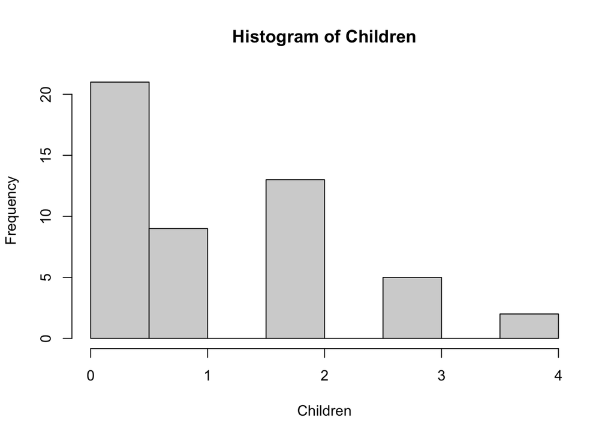

```r
hist(insurance$Children,
     main = 'Histogram of Children',
     xlab = 'Children',
     ylab = 'Frequency')
```

```r
var(insurance$Children)
```

```
## [1] 1.443265
```

```r
summary(insurance)
```

```
##     Charges           Age             BMI            Female        Children
##  Min.   : 1243   Min.   :18.00   Min.   :16.82   Min.   :0.00   Min.   :0.00
##  1st Qu.: 4089   1st Qu.:26.00   1st Qu.:26.30   1st Qu.:0.00   1st Qu.:0.00
##  Median : 7815   Median :38.00   Median :29.86   Median :1.00   Median :1.00
##  Mean   :10860   Mean   :39.32   Mean   :30.02   Mean   :0.52   Mean   :1.16
##  3rd Qu.:12542   3rd Qu.:52.00   3rd Qu.:33.75   3rd Qu.:1.00   3rd Qu.:2.00
##  Max.   :45702   Max.   :64.00   Max.   :43.34   Max.   :1.00   Max.   :4.00
##      Smoker    WinterSprings    WinterPark       Oviedo
##  Min.   :0.0   Min.   :0.00   Min.   :0.00   Min.   :0.00
##  1st Qu.:0.0   1st Qu.:0.00   1st Qu.:0.00   1st Qu.:0.00
##  Median :0.0   Median :0.00   Median :0.00   Median :0.00
##  Mean   :0.1   Mean   :0.26   Mean   :0.22   Mean   :0.16
##  3rd Qu.:0.0   3rd Qu.:0.75   3rd Qu.:0.00   3rd Qu.:0.00
##  Max.   :1.0   Max.   :1.00   Max.   :1.00   Max.   :1.00
```

```r
sd(insurance$Charges)
```

```
## [1] 9883.391
```

```r
sd(insurance$Age)
```

```
## [1] 14.34906
```

```r
sd(insurance$BMI)
```

```
## [1] 6.233444
```

```r
sd(insurance$Children)
```

```
## [1] 1.20136
```

```r
getModes <- function(x) {
ux <- unique(x)
tab <- tabulate(match(x, ux))
ux[tab == max(tab)]
}

getModes(insurance$Charges)
```

```
##  [1]  3972.925  1242.816 45702.022 12235.839  9630.397 33750.292  5846.918
##  [8] 21195.818 11286.539  2842.761  4779.602 27808.725  7050.021 10214.636
## [15]  2789.057 12044.342  9910.360  6406.411  2867.120 10370.913 25992.821
## [22]  8733.229  4718.204  3481.868  4438.263  8428.069  6640.545  3877.304
## [29]  7201.701 17878.901  3378.910 38746.355  4561.189  2150.469 11454.022
## [36] 12950.071  2534.394 26467.097  4894.753  2026.974  5138.257 14988.432
## [43]  1719.436 11987.168  7133.903 20878.784  8988.159  2632.992 12644.589
## [50] 14394.398
```

```r
getModes(insurance$Age)
```

```
## [1] 55 18 25
```

```r
getModes(insurance$BMI)
```

```
## [1] 29.830 33.345
```

```r
getModes(insurance$Children)
```

```
## [1] 0
```

Univariate Anaysis

Charges - Unimodal, not symmetrical, positively skewed as the mean is greater than the median with a Standard Deviation of 9883.391. Age- Bimodal,Not Symmetrical, slightly skewed right with a Standard Deviation of 14.34906. BMI- Unimodal, Symmetrical, non skewed with a Standard Deviation of 6.233444. Children- Unimodal, Not Symmetrical, skewed to the right with a Standard Deviation of 1.20136.

# Question 2

Perform bivariate analyses on the quantitative variables (direction, strength and form). Describe the linear association between all variables.

```r
insurance$Smoker <- NULL
insurance$WinterSprings <- NULL
insurance$WinterPark <-NULL
insurance$Oviedo <-NULL
insurance$Female <- NULL

cor(insurance)
```

```
##            Charges         Age        BMI    Children
## Charges  1.0000000  0.40851021 0.26010167  0.11947122
## Age      0.4085102  1.00000000 0.06023366 -0.01013401
## BMI      0.2601017  0.06023366 1.00000000  0.08159277
## Children 0.1194712 -0.01013401 0.08159277  1.00000000
```

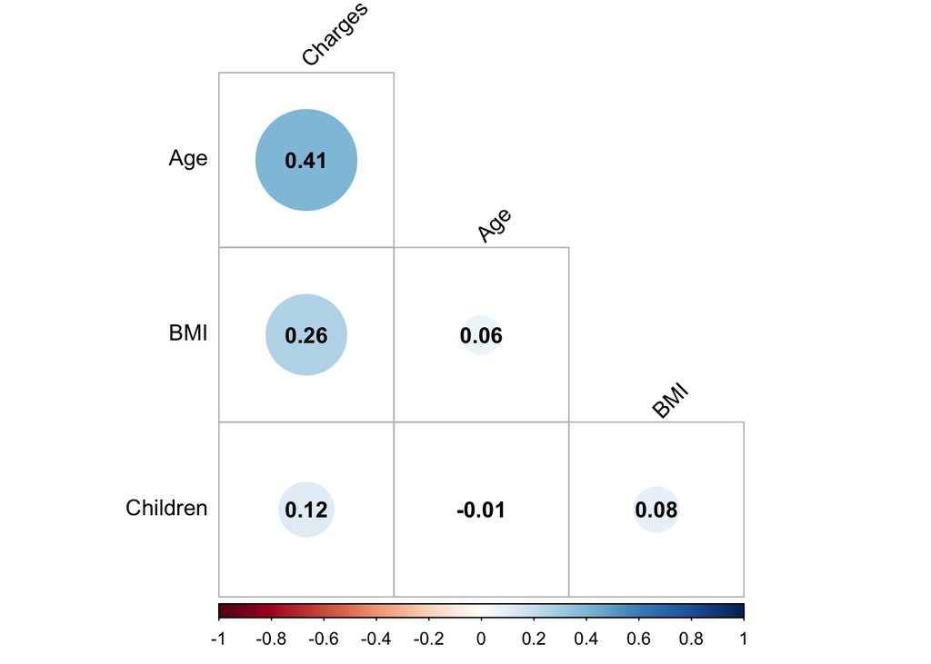

```r
corrplot(cor(insurance),
type = "lower",
order = "hclust",
tl.col = "black",
tl.srt = 45,
addCoef.col = "black",
diag = FALSE)
```

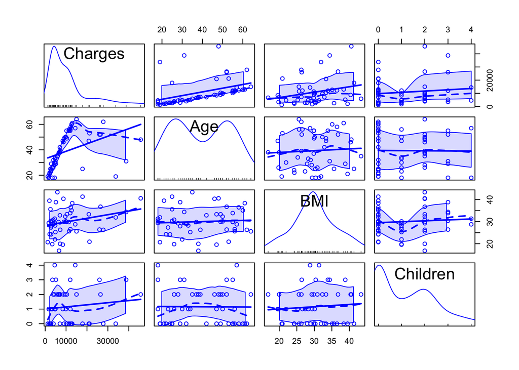

```r
scatterplotMatrix(insurance)
```

# Question 3

Generate a regression equation in the following form:

$$Charges =
\beta_{0}+\beta_{1}*Age+\beta_{2}*BMI+\beta_{3}*Children$$

```r
model <- lm(Charges ~ Age + BMI + Children, data = insurance)

summ(model)
```

```
## MODEL INFO:
## Observations: 50
## Dependent Variable: Charges
## Type: OLS linear regression
##
## MODEL FIT:
## F(3,46) = 4.67, p = 0.01
## R² = 0.23
## Adj. R² = 0.18
##
## Standard errors: OLS
## -------------------------------------------------------
##                          Est.      S.E.   t val.      p
## ----------------- ----------- --------- -------- ------
## (Intercept)         -11700.62   7054.72    -1.66   0.10
## Age                    272.66     89.09     3.06   0.00
## BMI                    361.03    205.75     1.75   0.09
## Children               863.03   1065.66     0.81   0.42
## -------------------------------------------------------
```

also write out the regression cleanly in this document.

```
    Charges = -11700.62 + 272.66Age + 361.03BMI + 863.03Children
```

# Question 4

An eager insurance representative comes back with a potential client. The client is 40, their BMI is 30, and they have one dependent. Using the regression equation above, predict the amount of medical expenses associated with this policy. (Provide a 95% confidence interval as well)

```r
newPrediction <- data.frame(Age = 40,
                            BMI= 30,
                            Children = 1)
predict(model, newdata = newPrediction)
```

```
##        1
## 10899.59
```

```r
predict(model,
        newdata = newPrediction,
        interval = "confidence",
        level = .95)
```

```
##        fit      lwr      upr
## 1 10899.59 8331.644 13467.54
```